# EDA Project - Explore and Summarize Data - Red Wine Quality

Daniel

19 December 2017

### 1. Introduction

We start with obtaining a summary of the dataset:

```
##        X          fixed.acidity   volatile.acidity  citric.acid
##  Min.   :   1.0   Min.   : 4.60   Min.   :0.1200   Min.   :0.000
##  1st Qu.: 400.5   1st Qu.: 7.10   1st Qu.:0.3900   1st Qu.:0.090
##  Median : 800.0   Median : 7.90   Median :0.5200   Median :0.260
##  Mean   : 800.0   Mean   : 8.32   Mean   :0.5278   Mean   :0.271
##  3rd Qu.:1199.5   3rd Qu.: 9.20   3rd Qu.:0.6400   3rd Qu.:0.420
##  Max.   :1599.0   Max.   :15.90   Max.   :1.5800   Max.   :1.000
##  residual.sugar     chlorides       free.sulfur.dioxide
##  Min.   : 0.900   Min.   :0.01200   Min.   : 1.00
##  1st Qu.: 1.900   1st Qu.:0.07000   1st Qu.: 7.00
##  Median : 2.200   Median :0.07900   Median :14.00
##  Mean   : 2.539   Mean   :0.08747   Mean   :15.87
##  3rd Qu.: 2.600   3rd Qu.:0.09000   3rd Qu.:21.00
##  Max.   :15.500   Max.   :0.61100   Max.   :72.00
##  total.sulfur.dioxide    density             pH          sulphates
##  Min.   :  6.00       Min.   :0.9901   Min.   :2.740   Min.   :0.3300
##  1st Qu.: 22.00       1st Qu.:0.9956   1st Qu.:3.210   1st Qu.:0.5500
##  Median : 38.00       Median :0.9968   Median :3.310   Median :0.6200
##  Mean   : 46.47       Mean   :0.9967   Mean   :3.311   Mean   :0.6581
##  3rd Qu.: 62.00       3rd Qu.:0.9978   3rd Qu.:3.400   3rd Qu.:0.7300
##  Max.   :289.00       Max.   :1.0037   Max.   :4.010   Max.   :2.0000
##     alcohol         quality
##  Min.   : 8.40   Min.   :3.000
##  1st Qu.: 9.50   1st Qu.:5.000
##  Median :10.20   Median :6.000
##  Mean   :10.42   Mean   :5.636
##  3rd Qu.:11.10   3rd Qu.:6.000
##  Max.   :14.90   Max.   :8.000
```

Our dataset contains 13 variables, with 1599 observations.

#### 1.1 Wine Quality

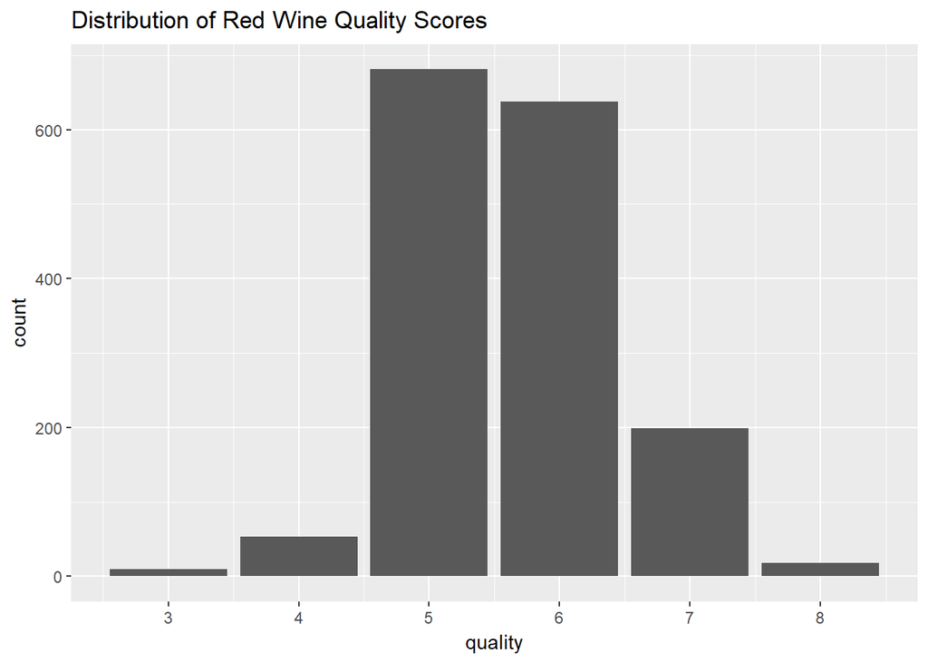

Observations:

1. The distribution is bimodal: Most wine are given a score of either 5 or 6.
2. This is an unbalanced dataset - the vast majority of observations are of wines with quality ratings 5 and 6. In particular, there are only 10 wines of very poor quality (rating 3) and only 18 wines of very good quality (rating 8). We will have to bear this in mind when trying to parse out relationships with quality and other variables in the dataset.

### 2. Bivariate Plots - Wine Quality

Choice of Plot: Looking at the summary of the variables above in section 1, I noted that the quality variable was in a discrete numerical scale, while many of the chemical variables are in continuous numerical scales. These data features suggest that boxplots, with quality in the x-axis, and continuous variables in the y-axis, could be appropriate as preliminary bivariate plots to illustrate basic relationships between quality and other variables.

#### 2.1 Acidity and Quality

##### Fixed Acidity (Tartatic Acid)

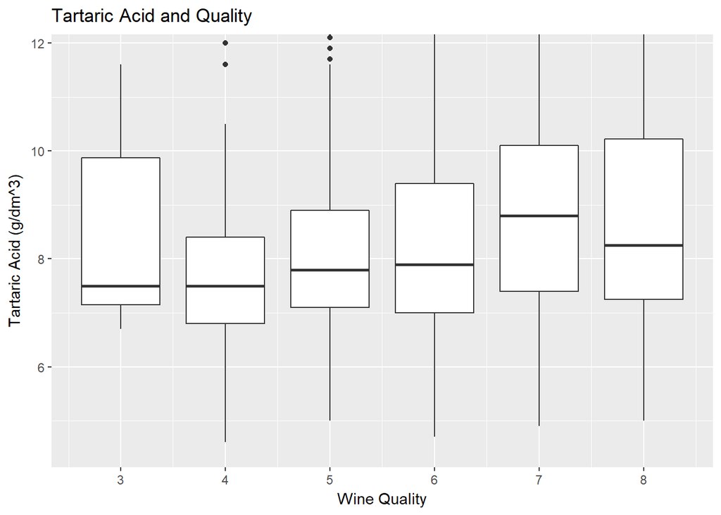

Observation: There is no clear trend between fixed acidity and quality here. Using the amount of ‘overlap’ between the boxplots as a first crude approximation of whether fixed acidity matters, the differences in fixed acidity between wines of different quality are not large, and hence do not (by themselves) account for much of the differences in quality.

##### Volatile Acidity (Acetic Acid)

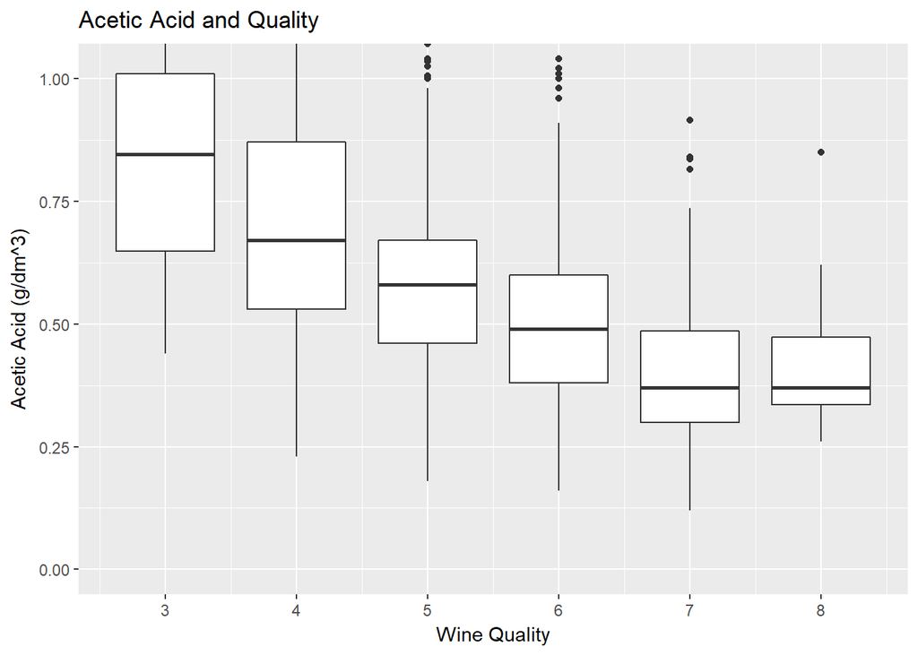

##### Citric Acid

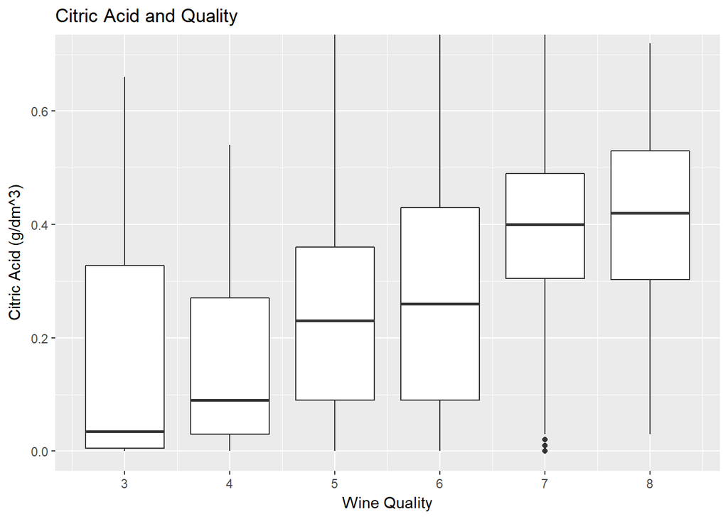

Observations:

1. Although there is more overlap between the boxplots here compared to the volatile acidity-quality plot in para 3.1.2, there is a clear trend between the median citric acid and quality: the more citric acid, the higher the quality. The trend is not linear - We observe two discontinuous jumps in the median citric acid: from quality 4 to 5, and from 6 to 7.
2. Drawing on domain knowledge, we know from the wine quality info text file that citric acid “can add ‘freshness’ and flavor to wines”. This agrees with the positive relationship we have observed in the plot.

#### 2.2. Sulfur Dioxide and Sulphites

##### Total Sulfur Dioxide

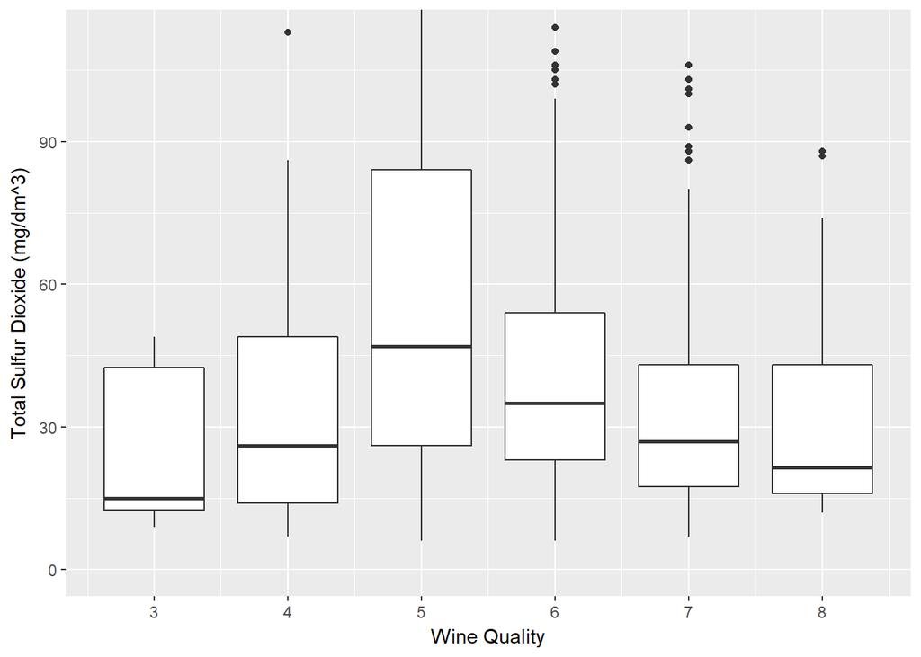

Observations:

1. We observe a crude ‘inverse U shaped’ relationship: Wines of quality 5 have a significantly higher amount of total sulfur dioxide than wines of quality 3 and 4. However, the opposite is true for wines of quality 6,7,8 vs. 5.
2. We know from the red wine text file that SO2 (at least the free form SO2) prevents microbial growth and the oxidation of wine. Hence the jump in SO2 between wines of quality 4 and 5 is not surprising.
3. We further note that the text file for the red wine data specifies that “in low concentrations, SO2 is mostly undetectable in wine, but at free SO2 concentrations over 50 ppm, SO2 becomes evident in the nose and taste of wine”. Perhaps this explains that despite its role as a preservative, levels of SO2 for wines of quality 6 and above hardly exceed 50 ppm, as seen in the boxplot.

##### Free Sulfur Dioxide

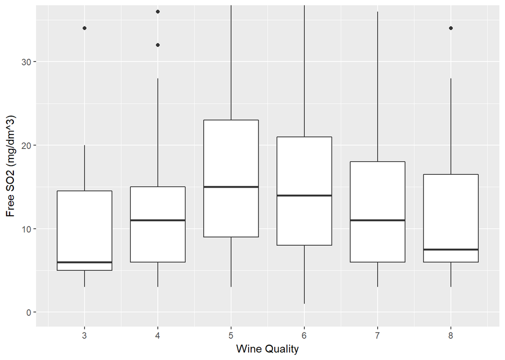

Observation: Unsurprisingly, given free SO2’s role as wine preservative, the qualitative patterns observed in this chart are similar to that of the boxplot with total SO2.

##### Sulphates

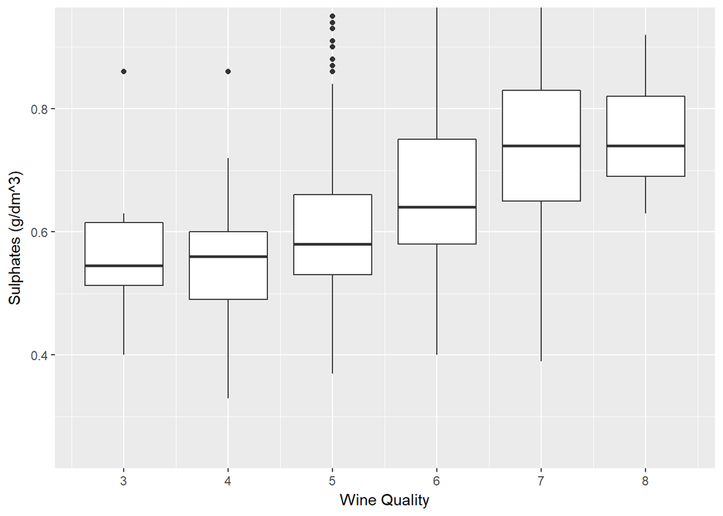

Observations:

1. We observe a upward trend here: Generally, the higher the quality of wine, the more sulphates it contains.
2. Looking at the red wine text file, we know that sulphates are a wine additive that acts as a antimicrobial and antioxidant. So it is not too surprising that wine above passable quality (score 5) have higher sulphite levels than those below passable quality.

#### 2.3. Sugar and Chlorides

##### Residual Sugar

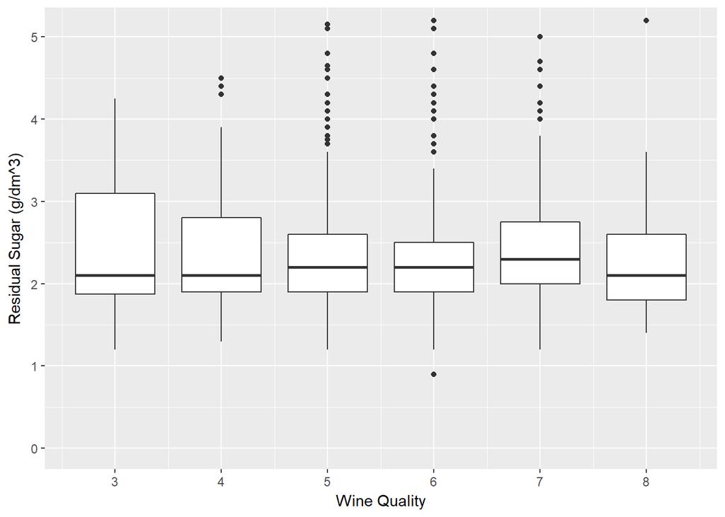

Observation: There are no significant differences in residual sugar levels across wine quality.

##### Chlorides

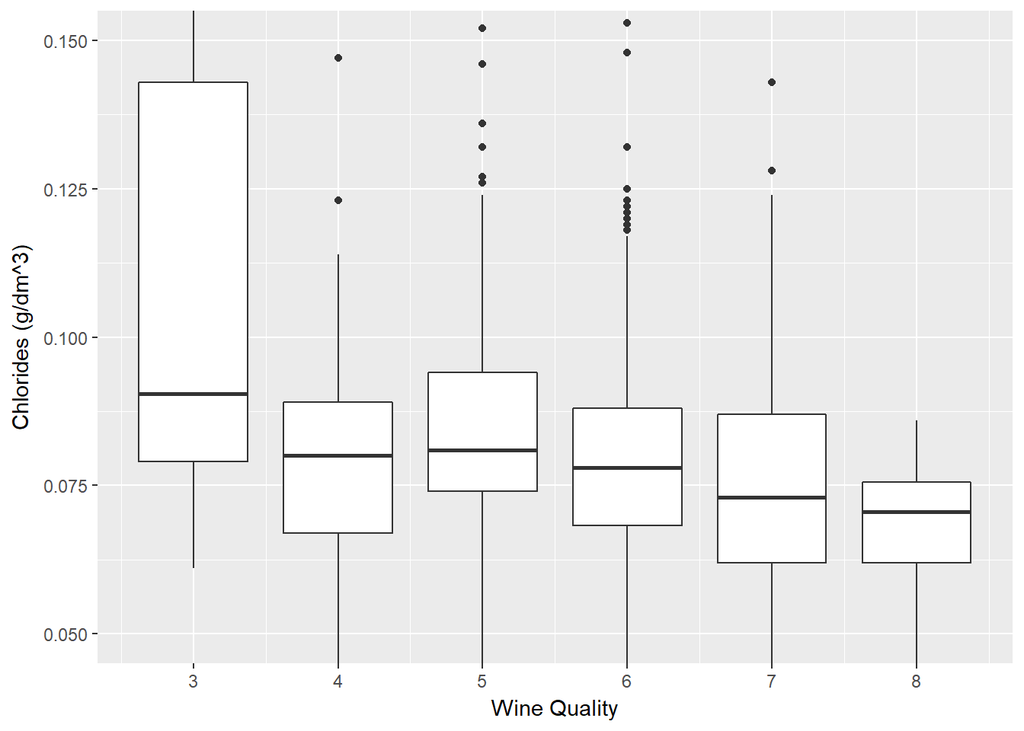

#### 2.4 Density, pH and Alcohol Content

##### Density

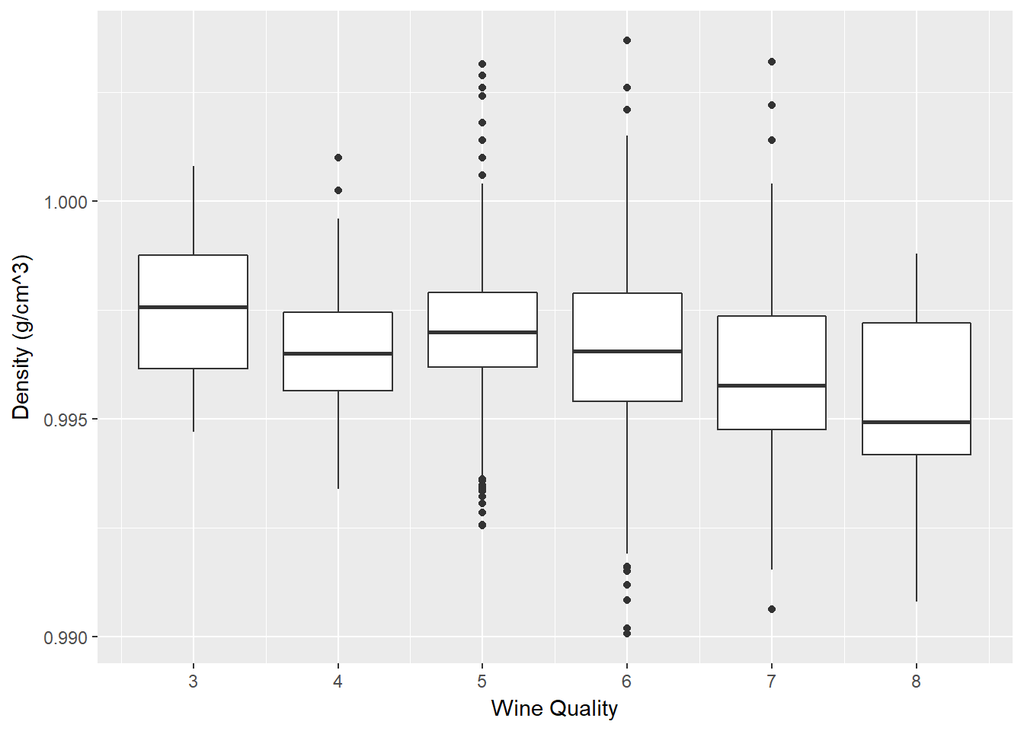

Observation: There is a slight downward trend in density as wine quality increases for wines of quality ratings 5 to 8.

##### pH

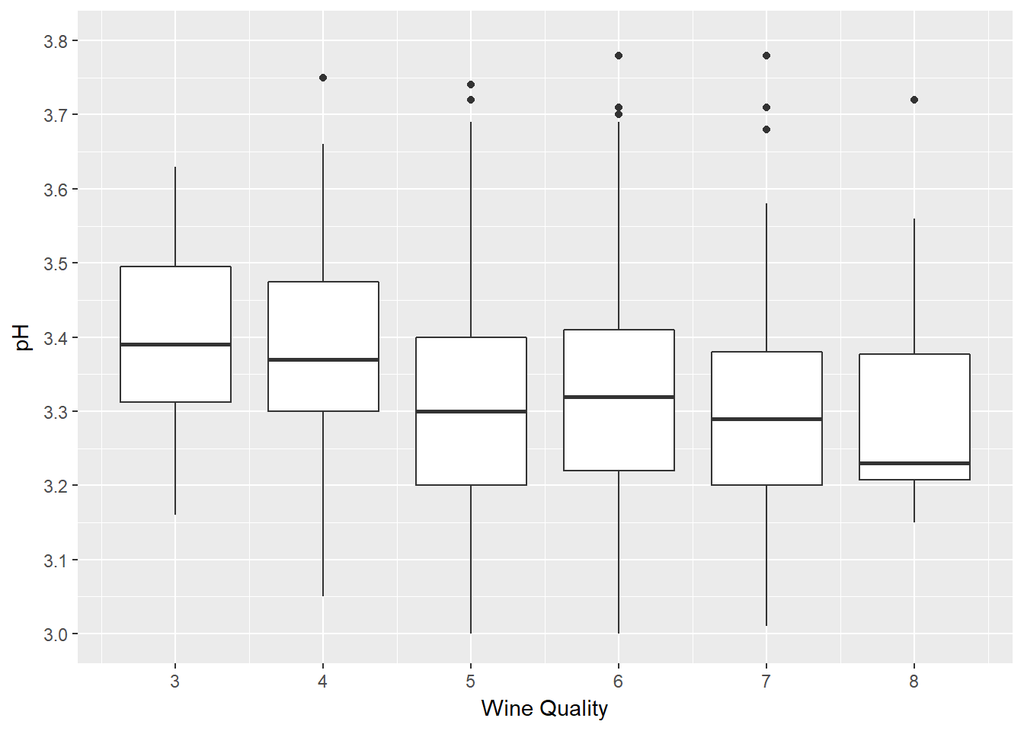

Observation: Most of the wines are between 3.0 and 3.5 pH. This is not surprising, since most wines are acidic. Lower pH seems to be associated with higher quality wines.

##### Alcohol Content

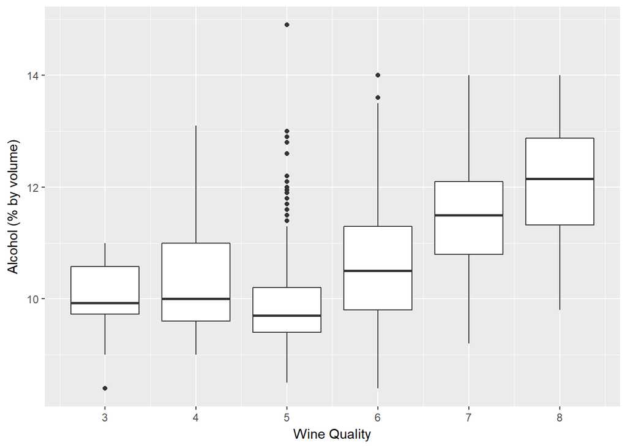

Observation: There is a clear upward trend between alcohol and quality across wines of quality 5 - 8. The implications of this finding are unclear at this point however. Do the wine raters like stronger alcohol? Or are higher alcohol concentrations reflective of better tasting wine, which is in turn the by-product of better quality grapes/yeast/other inputs used in winemaking?

### 3. Bivariate Relationships between Non-Wine Quality variables

The above bivariate plots demonstrate that many of the variables have some correlation with wine quality. In the next section, I look into the cross-relationships between variables to determine the extent to which they are correlated to one another, and conduct some data transformations to create new variables in obtaining new relationships.

#### 3.1 Relationships between Acidity Variables

##### Acetic Acid (Volatile Acidity) and Tartaric Acid (Fixed Acidity)

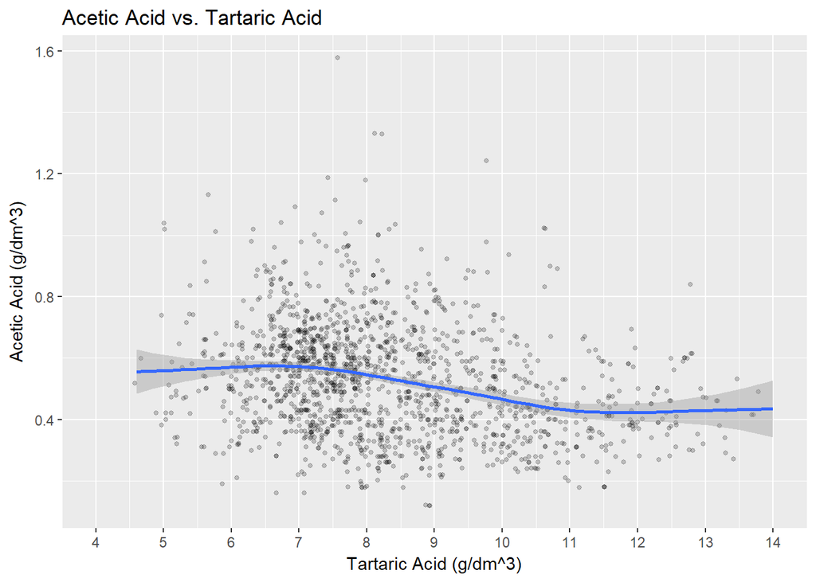

Observation: There is not much of a relationship between acetic acid and tartaric acid.

##### Citric Acid and Tartaric Acid

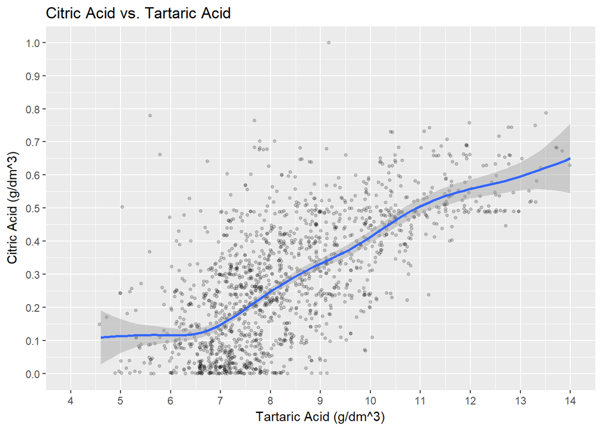

Observation: From tartaric acid concentrations of 7g/dm^3 onwards, there is a clear positive relationship between fixed acidity and citric acid.

##### Acetic Acid and Citric Acid

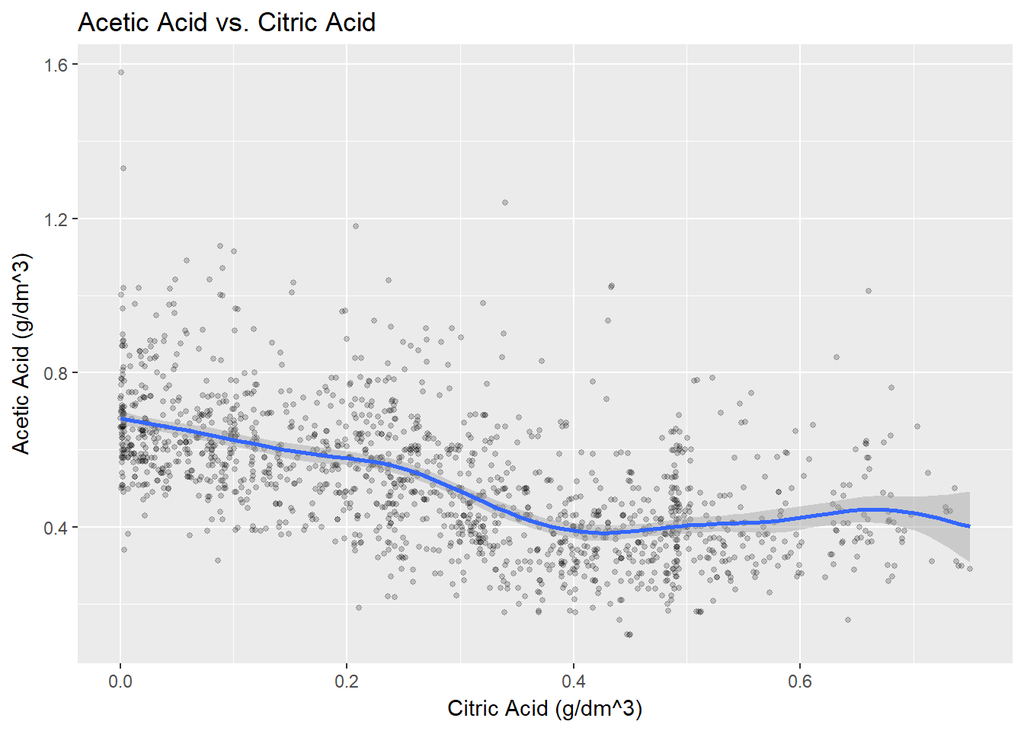

Observation: There is a decreasing relationship between the two variables for citric acid range 0 to 0.4, but no relationship thereafter.

#### 3.2 Relationships between S02 Variables

##### Total SO2 and Free SO2

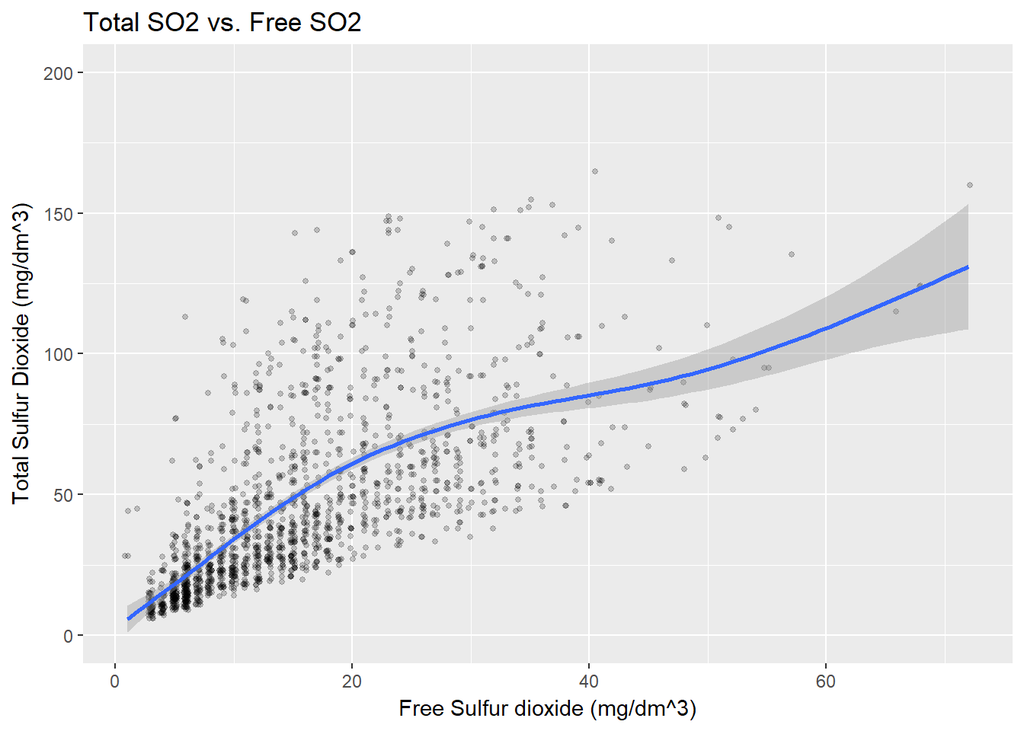

Observation: The positive correlation of free SO2 and total S02 is unsurprising, given that free sulfur dioxide is part of the total SO2.

##### Total SO2 and Sulphates

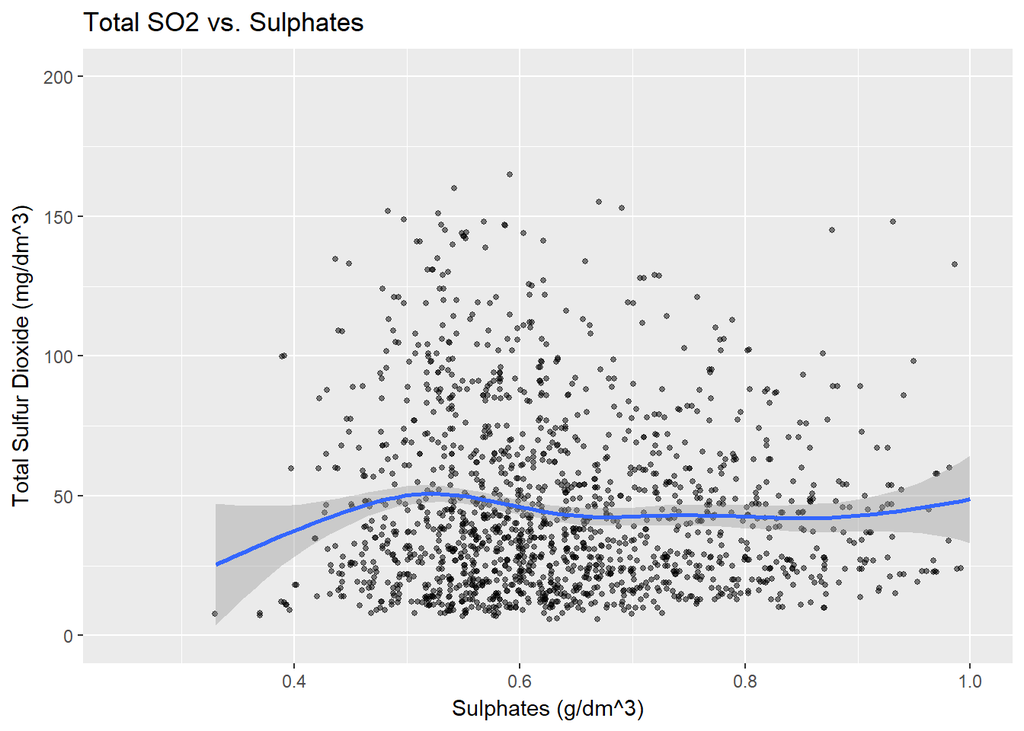

Observation: The lack of relationship between total SO2 and sulphates is unexpected, given that sulphates is described as a contributor to SO2 gas levels in the red wine text file. Perhaps sulphates do not convert to SO2 beyond a certain level of S02/sulphate concentration in the wine.

##### Free SO2 and Sulphates

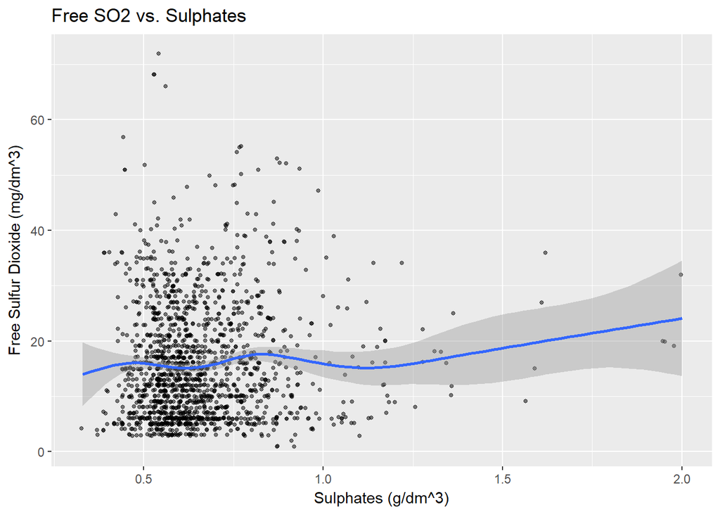

Observation: Similar to the above, there is no discernible relationship between sulphates and free SO2.

Sum-up: It appears that sulphates and the two SO2 variables are not correlated, which is surprising.

### 4. Alcohol Content, ‘Impurities’, Density and Wine Quality: A Multivariate Exploration

I was intrigued by the strong positive correlation between alcohol content of the wine and the quality found in section 2.4. As mentioned then, it is not clear whether (i) wine tasters simply like “stronger” wines, or whether (ii) wines with higher alcohol content also had better tasting wine, due to other underlying factors. Perhaps the relative abundance of some chemicals with wine preservation characteristics could increase the alcohol content.

#### 4.1 Alcohol Content

Observations:

So observation 2 suggests that alcohol content is not strongly correlated with chemical content. Yet we notice the strong correlation that density has with alcohol.

This lead me to question: Could higher density imply the presence of more “impurities” and thus result in poorer wine quality? Could the negative correlation between density and alcohol variable merely be reflecting the cumulative amount of different impurities (the more impurities, the higher the density) and their impact on alcohol content?

##### Alcohol Content, Density, and Quality

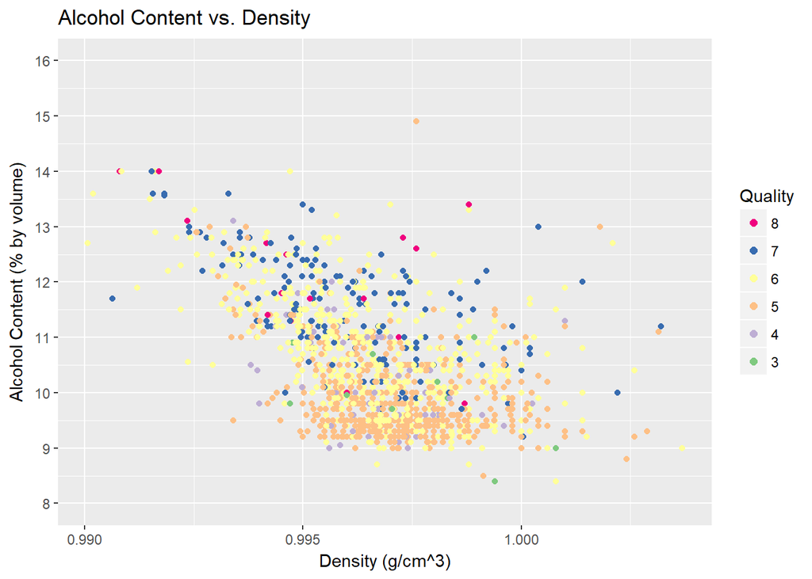

Observation: We notice a negative correlation between alcohol content and density. Moreover, even after controlling for density, higher alcohol content is associated with higher quality wines.

I then used the following code to generate four new variables which measured the concentration of compounds in wine (R code is reproduced below):

This variable refers to chemical variables with a positive correlation with wine quality: rw$compounds.good = with(rw, citric.acid + sulphates)

This variable refers to chemical variables with a negative correlation with wine quality. Note that I had to divide total.sulfur.dioxide by 1000 to ensure consistency in the units (g/dm^3):

rw$compounds.bad = with(rw, volatile.acidity + chlorides + total.sulfur.dioxide/1000)

This variable refers to chemical variables with no significant correlation with wine quality: rw$compounds.neutral = with(rw, fixed.acidity + residual.sugar)

Finally, I created a ‘rw$compounds.total variable’, which is the sum of the three variables above.

#### 4.2 Density and Compound Content

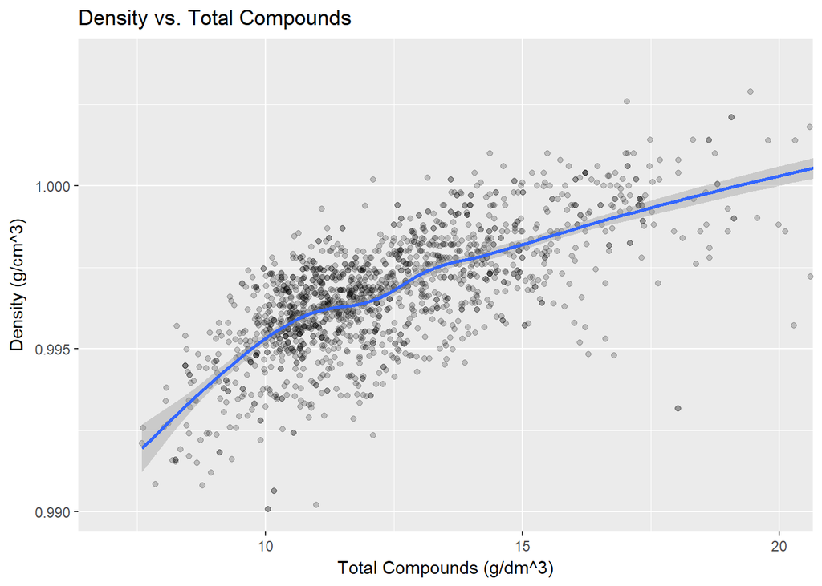

Observation: We see a clear positive trend between density and total compound content (the ‘compounds.total’ variable). Moreover, the correlation is significant at ~0.715.

#### 4.3 Wine Quality and Compound Content

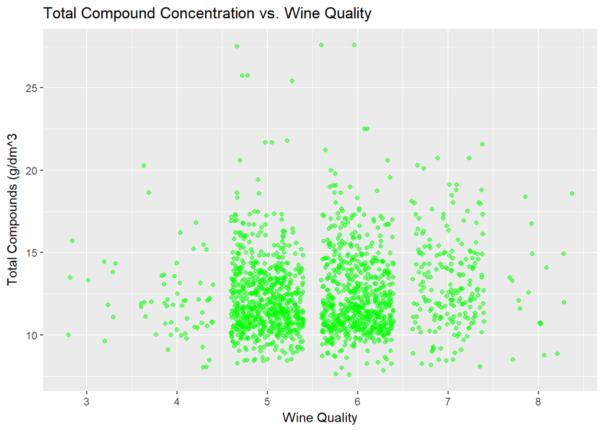

Observation: We do not discern any trends here. However, plotting the compounds.good vs. compounds.bad variables against quality yields interesting findings:

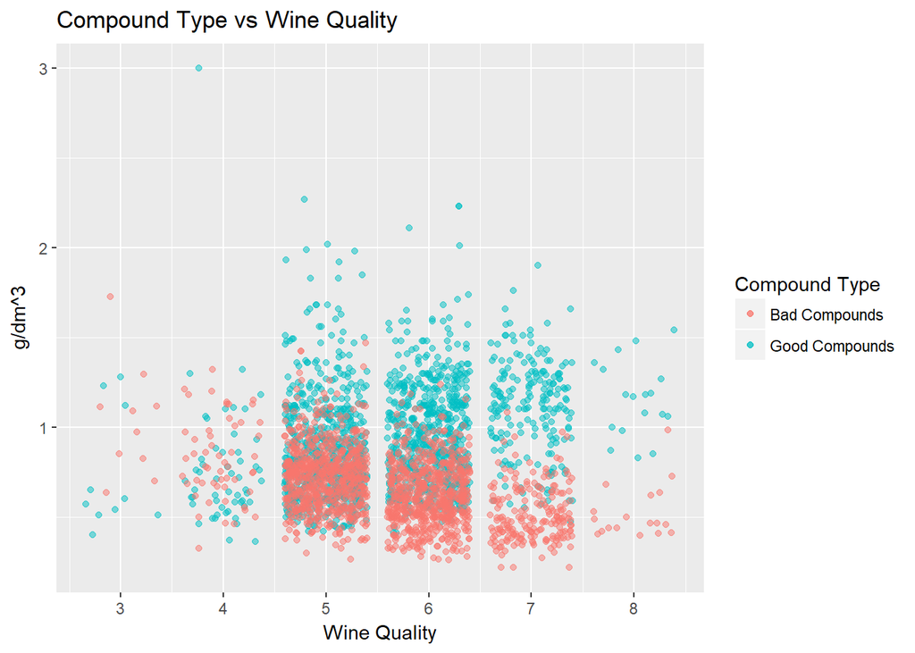

Observation: We see that the ratio of ‘good’ to ‘bad’ compounds increases with wine quality.

Sum-up: This analysis demonstrates the following:

1. The negative relationship between alcohol content and density cannnot be explained by the relative abundance/scarcity of ‘impurities’ in the wine.
2. It follows from point 1 therefore that the positive relationship between alcohol content and wine quality cannot be accounted for by the ‘impurities’. Perhaps it just may be that wine tasters prefer wines with higher alcohol content, since wines with higher alcohol content could have more accentuated flavours.
3. On the flip side, this also demonstrates that the correlation of the ‘impurities’ with wine quality are not drawn from any correlation with alcohol content.

### 5. Analysis of pH

I conducted an analysis of pH with acidity, SO2, and sugar/chloride variables.

#### Acidity and pH

I created a new variable called ‘compounds.acidity’ by summing up the concentrations of all three acid-related variables (fixed.acidity, volatile.acidity, and citric.acid).

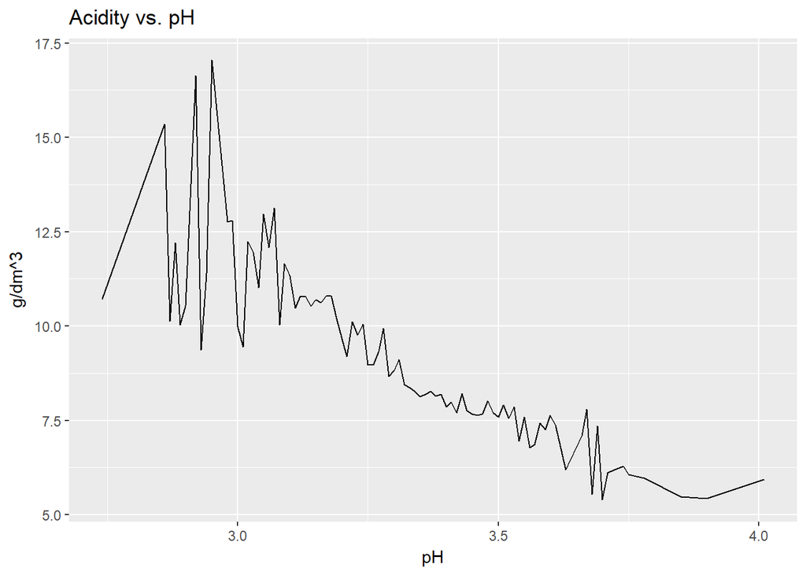

Observation: There is a strong negative correlation, which is expected since we know from basic chemistry that the higher the pH, the less acidic (and more basic) the substance.

I decided to break down the relationship between pH and each of the acid-related variables separately:

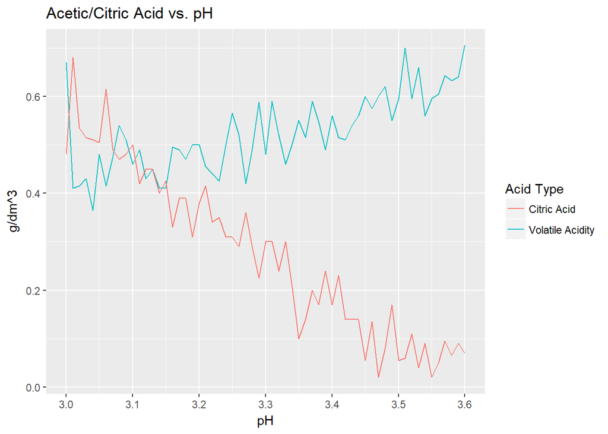

Observation: The strong downward correlation with citric acid is expected, but we find a surprising positive correlation between acetic acid and pH. We should not conclude that higher concentrations of acetic acid lead to higher pH, a spurious correlation, given that such a conclusion would contradict science. Computing correlations, I find that pH has a slightly positive correlation with alcohol content. Coupled with the negative correlation with alcohol that acetic acid had in section 4.1, this may be one driver of the upward sloping line.

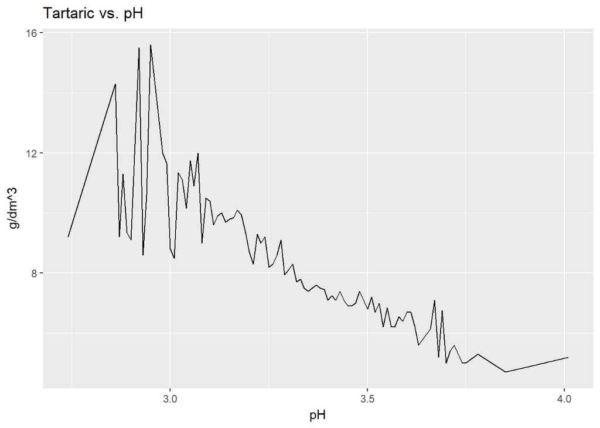

Observation: Nothing surprising here - the plot is extremely similar to that the plot against the compound.acidity variable - which can be explained by the fact that tartaric acid has the higher concentration of the three acid-related variables.

Sum-up: This analysis demonstrates that it would be possible to proxy for pH using acidity variables, if such a method is required, given the strong correlation between the two. However, one must proceed with caution, since cross-correlations with other variables could impact the reliability of acid-related variables as a proxy, as in the case with acetic acid.

#### SO2, Chlorides, Residual Sugar and pH

For brevity, I compute pairwise correlations for chlorides and residual sugar and SO2 variables. There are no significant correlations, which are expected. From basic chemistry we know that sodium chlorides and sulphates are salts, which have neutral pH. Sugar is also pH-neutral.

### 6. Balance

Finally, as an occasional wine drinker, I have heard the term ‘balance’ used many times to describe a wine, and it usually pertains to a wine’s acidity versus its sweetness. I thus created a new variable ‘balance’ by taking the ratio of acidity (compounds.acidity variable) and sweetness (residual.sugar variable):

I wonder if a higher ‘balance’ could lead to greater wine quality?

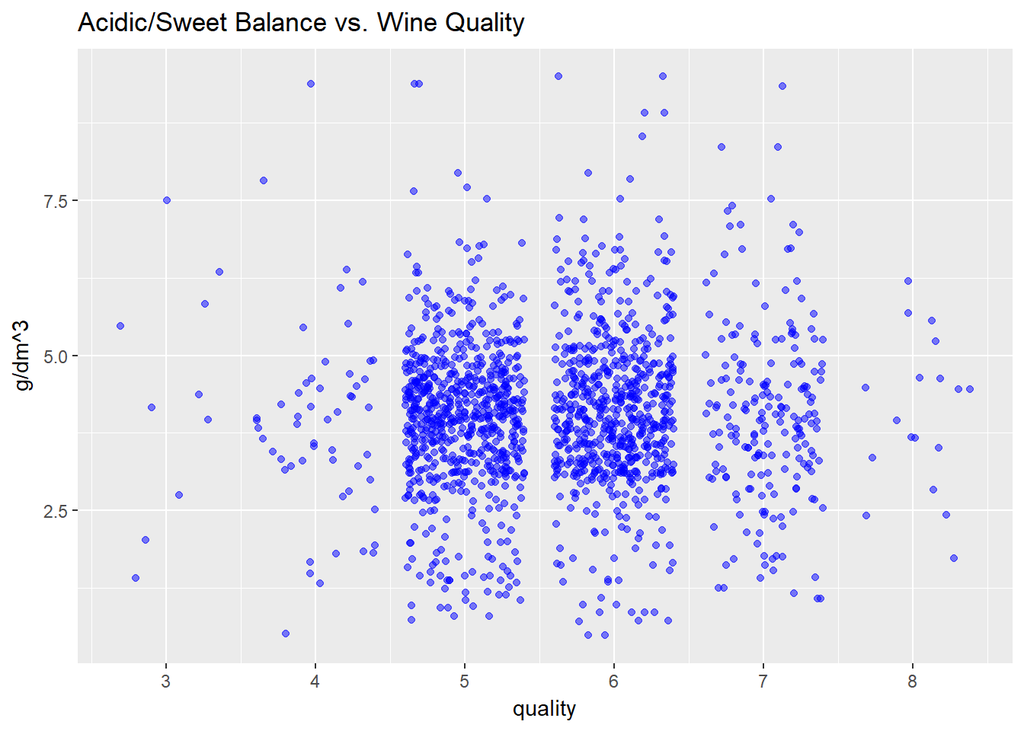

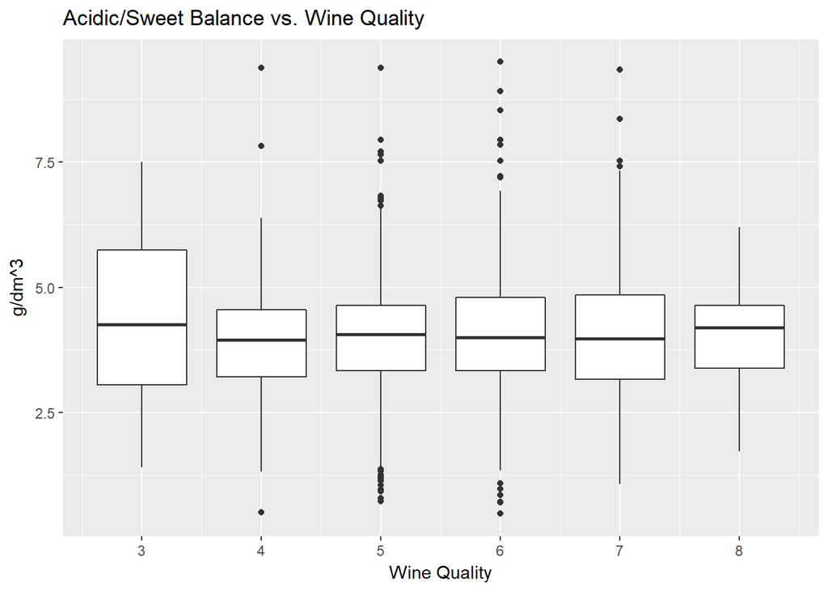

Observation: Somewhat disappointingly, I do not see any relationship between my measure of balance and wine quality.

### 7. Final Plots

#### Plot 1

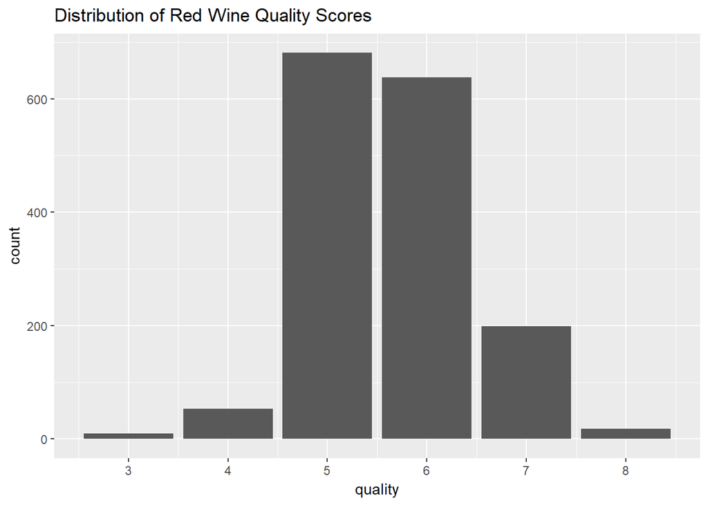

Observations:

1. The distribution is bimodal: Most wine are given a score of either 5 or 6. One could argue that it looks normal due to the mass being at the centre and the tails being thin, but the large bin width (1), coupled with the limited range of the quality variable, does not form a nice normal shape.
2. The tails of the distribution (quality 3 and 8 in particular) are extremely small.
3. In summary, this is a very unbalanced dataset. Consequently, it will be harder to accurately estimate the impacts of the various input variables (e.g. acidity, SO2 concentrations, density etc.) on wine quality, although not impossible.

#### Plot 2

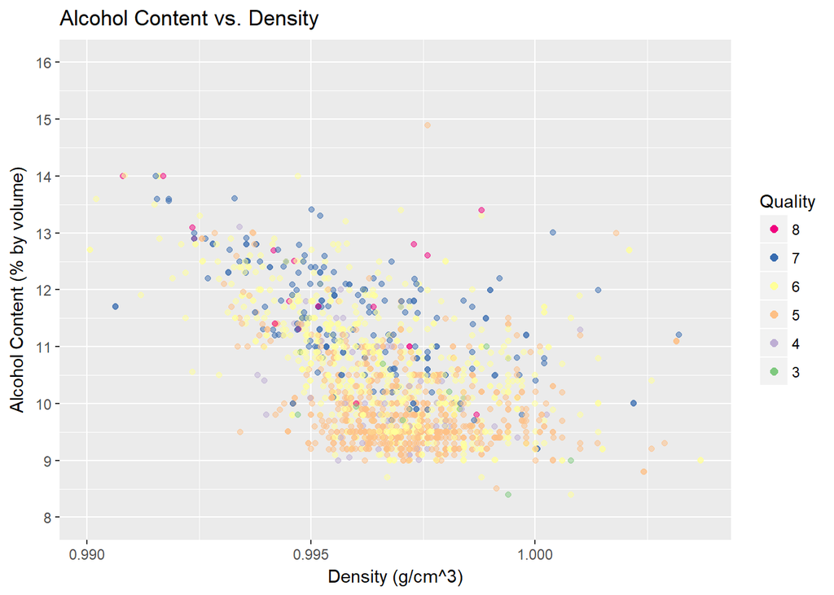

Observations:

1. Looking at the points in aggregate, we see a general negative correlation between alcohol content and density.
2. But this negative correlation is not perfect. There are still wines with high alcohol content that are relatively dense (e.g. there are many wines of quality 7 for densities above 0.9975.)
3. Controlling for density, the higher the alcohol content, the higher the wine quality. This is not surprising, since we know that higher alcohol content is also correlated with higher wine quality.

#### Plot 3

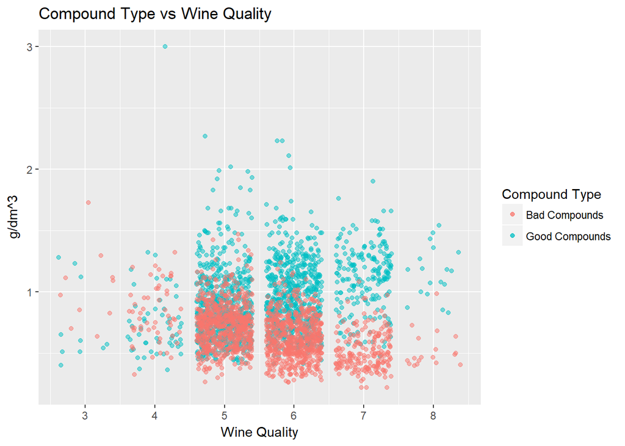

Observations:

1. This plot helps to visualize the effect of the various chemical compounds on wine quality by plotting both the ‘bad compounds’ (i.e. compounds that have a negative correlation with wine quality) and the ‘good compounds’ (those that have a positive correlation with wine quality) across wine quality.
2. As we move from the lowest to the highest wine quality, the “mix” of bad/good compounds evolve: the higher the wine quality, the greater the good compounds relative to the bad compounds, which we can see by the greater ‘separation’ between the good and the bad compounds. (I could have also illustrated the same thing via a ratio plot, but this scatterplot makes the good/bad compound mix more visually compelling in my opinion.)

### 8. Reflections

In this project, I analyzed red wine data to gain insights into which factors were important in determining wine quality. Using a range of bivariate and multivariate plots, I managed to discern relationships between chemicals (such as acid and SO2), as well as wine characteristics (such as alcohol content, density and pH) with wine quality ratings. I also found correlations between the input variables themselves, and this could come in useful when trying to specify a regression model without using an excessive number of parameters (e.g. replacing pH with acidity variables).

However, the unbalanced nature of the dataset posed a major difficulty in conducting the analysis. Specifically, having limited variation in the wine quality variable - with most of the data pertaining only to wine quality 5 and 6 - made it difficult to tease out how the other variables affected wine quality. The fact that most correlations were weak (less than 0.5 in magnitude) could have been one manifestation of this.

The analysis could be enriched through better data, the specifics of which are: - A more balanced dataset: I recognize that it is certainly infeasible to ask for equal number of observations for each wine quality (since wine quality is probably normally distributed and wine experts rarely give extremely bad or extremely good wine quality ratings.). However, it would certainly have helped if more of the data were of wine quality 3-4/7-8. Perhaps a bigger dataset would have more of such observations. - Geography of the wine included as a variable: It is well known that wines from different regions of the world taste different because of the different soils and climate, and consequently varied grape characteristics. It would have been ideal to have these information included. It would have enabled an additional dimension of analysis of geography - for instance, to see if different geographies produced more acidic wines, or even whether the wine quality tasters appeared to be biased towards a specific region, even if the chemical/physical properties of the wines were the same.